# Laboratorio 6

integrantes:

```
- Francis Aguilar - 22243
- Angela García -22869
- Cesar Lopez - 22535
```

enlace al repositorio: https://github.com/faguilarleal/lab6_ds

Detalle del análisis: Analisis del proyecto

```python
import pandas as pd
import unicodedata
import string
import nltk
import re
from nltk.corpus import stopwords
from collections import Counter

from wordcloud import WordCloud
import matplotlib.pyplot as plt
import networkx as nx

import community as community_louvain
import collections

# ----- Análisis de tópicos con LDA (sklearn) -----
import numpy as np
from sklearn.feature_extraction.text import CountVectorizer
from sklearn.decomposition import LatentDirichletAllocation


import stopwordsiso as stopwords
import json
from pathlib import Path
from nltk.sentiment import SentimentIntensityAnalyzer
from networkx.algorithms.community import greedy_modularity_communities
import seaborn as sns
```

## Descripcion general de los datos

```python
def _detectar_encoding(path: str) -> str:
    with open(path, 'rb') as fb:
        bom = fb.read(2)
    # UTF-16 BOMs
    if bom in (b'\xff\xfe', b'\xfe\xff'):
        return 'utf-16'
    return 'utf-8'

def cargar_jsonl_seguro(path: str, encoding: str | None = None, max_warn: int = 5):
    if encoding is None:
        encoding = _detectar_encoding(path)
    data, malas = [], []
    with open(path, 'r', encoding=encoding) as f:
        for i, line in enumerate(f, start=1):
            line = line.strip()
            if not line:
                continue
            try:
                data.append(json.loads(line))
            except json.JSONDecodeError as e:
                malas.append((i, str(e)))
                if len(malas) <= max_warn:
                    print(f"[warn] línea {i}: {e}. -> se omite")
    return data, malas, encoding

# Selector de dataset
DATASET = "tioberny"
FNAME = "tioberny.txt" if DATASET == "tioberny" else "traficogt.txt"

# Carga
registros, lineas_malas, ENCODING = cargar_jsonl_seguro(FNAME)

# DataFrame
df = pd.DataFrame(registros)

print(f"Dataset cargado: {DATASET} -> {FNAME} | encoding={ENCODING}")
print(f"Registros válidos: {len(df)}  |  líneas omitidas: {len(lineas_malas)}")
print(df.shape)
```

```
Dataset cargado: tioberny -> tioberny.txt | encoding=utf-16
Registros válidos: 5019  |  líneas omitidas: 0
(5019, 32)
```

```python
F1 = "tioberny.txt"
F2 = "traficogt.txt"

reg1, bad1, enc1 = cargar_jsonl_seguro(F1)
reg2, bad2, enc2 = cargar_jsonl_seguro(F2)

df1 = pd.DataFrame(reg1)
df2 = pd.DataFrame(reg2)

print(f"{F1}: {len(df1)} registros válidos | {len(bad1)} líneas omitidas | encoding={enc1}")
print(f"{F2}: {len(df2)} registros válidos | {len(bad2)} líneas omitidas | encoding={enc2}")

cols1 = set(df1.columns)
cols2 = set(df2.columns)

solo_en_1 = sorted(cols1 - cols2)
solo_en_2 = sorted(cols2 - cols1)
comunes   = sorted(cols1 & cols2)

print("\n--- Columnas solo en tioberny.txt ---")
print(solo_en_1 if solo_en_1 else ["(ninguna)"])

print("\n--- Columnas solo en traficogt.txt ---")
print(solo_en_2 if solo_en_2 else ["(ninguna)"])
```

```
[warn] línea 5605: Expecting ',' delimiter: line 1 column 4314 (char 4313). -> se omite
tioberny.txt: 5019 registros válidos | 0 líneas omitidas | encoding=utf-16
traficogt.txt: 5604 registros válidos | 1 líneas omitidas | encoding=utf-16

--- Columnas solo en tioberny.txt ---
['(ninguna)']

--- Columnas solo en traficogt.txt ---
['(ninguna)']
```

```python
def _ensure_list_column(df, col):
    if col not in df.columns:
        # crear columna con listas vacías (una lista distinta por fila)
        df[col] = [[] for _ in range(len(df))]
    else:
        df[col] = df[col].apply(lambda v: v if isinstance(v, list) else ([] if (pd.isna(v) or v is None) else [v]))

for col in ["cashtags", "hashtags", "mentionedUsers", "mentionedUsersID"]:
    _ensure_list_column(df, col)

print("Columnas opcionales aseguradas:", [c for c in ["cashtags","hashtags","mentionedUsers","mentionedUsersID"] if c in df.columns])
```

```
Columnas opcionales aseguradas: ['cashtags', 'hashtags', 'mentionedUsers', 'mentionedUsersID']
```

```python
print("RESUMEN DEL DATAFRAME")
print("="*40)

# Dimensiones
print(f"Total de filas: {df.shape[0]}")
print(f"Total de columnas: {df.shape[1]}\n")
```

```
RESUMEN DEL DATAFRAME
========================================
Total de filas: 5019
Total de columnas: 33
```

```python
df.info()
df.isna().sum()
```

```
<class 'pandas.core.frame.DataFrame'>
RangeIndex: 5019 entries, 0 to 5018
Data columns (total 33 columns):
 #   Column               Non-Null Count  Dtype
---  ------               --------------  -----
 0   id                   5019 non-null   int64
 1   id_str               5019 non-null   object
 2   url                  5019 non-null   object
 3   date                 5019 non-null   object
 4   user                 5019 non-null   object
 5   lang                 5019 non-null   object
 6   rawContent           5019 non-null   object
 7   replyCount           5019 non-null   int64
 8   retweetCount         5019 non-null   int64
 9   likeCount            5019 non-null   int64
```

[output cut: 25 more lines]

```
id                        0
id_str                    0
url                       0
date                      0
user                      0
lang                      0
rawContent                0
replyCount                0
retweetCount              0
likeCount                 0
quoteCount                0
bookmarkedCount           0
conversationId            0
conversationIdStr         0
hashtags                  0
cashtags                  0
mentionedUsers            0
links                     0
viewCount                81
retweetedTweet         5019
quotedTweet            4724
place                  4995
coordinates            5019
inReplyToTweetId        743
inReplyToTweetIdStr     743
inReplyToUser           649
source                    0
sourceUrl                 0
sourceLabel               0
media                     0
card                   4969
_type                     0
mentionedUsersID          0
dtype: int64
```

```python
df.head()
```

|  | id | id_str | url | date | user | lang | rawContent | replyCount | retweetCount | likeCount | ... | inReplyToTweetId | inReplyToTweetIdStr | inReplyToUser | source | sourceUrl | sourceLabel | media | card | _type | mentionedUsersID |
| --- | --- | --- | --- | --- | --- | --- | --- | --- | --- | --- | --- | --- | --- | --- | --- | --- | --- | --- | --- | --- | --- |
| 0 | 1834281080029110288 | 1834281080029110288 | https://x.com/La_ReVoluZzion/status/1834281080... | 2024-09-12 17:21:03+00:00 | {'id': 1435062946598694914, 'id_str': '1435062... | es | _\nConfirmado Compañeres,\n\nEl impuesto por l... | 0 | 0 | 0 | ... | NaN | None | None | <a href="http://twitter.com/download/android" ... | http://twitter.com/download/android | Twitter for Android | {'photos': [], 'videos': [], 'animated': []} | None | snscrape.modules.twitter.Tweet | [] |
| 1 | 1834252464092069901 | 1834252464092069901 | https://x.com/XelaNewsGt/status/18342524640920... | 2024-09-12 15:27:20+00:00 | {'id': 956650778634145792, 'id_str': '95665077... | es | #URGENTE Lo que los medios #faferos no informa... | 12 | 80 | 142 | ... | NaN | None | None | <a href="https://mobile.twitter.com" rel="nofo... | https://mobile.twitter.com | Twitter Web App | {'photos': [], 'videos': [{'thumbnailUrl': 'ht... | None | snscrape.modules.twitter.Tweet | [] |
| 2 | 1834280919336976681 | 1834280919336976681 | https://x.com/M24095273/status/183428091933697... | 2024-09-12 17:20:25+00:00 | {'id': 1087057038755143680, 'id_str': '1087057... | es | @IvanDuque @BArevalodeLeon Con que usaste PEGA... | 0 | 0 | 0 | ... | 1.834197e+18 | 1834197215415599186 | {'id': 77653794, 'id_str': '77653794', 'userna... | <a href="https://mobile.twitter.com" rel="nofo... | https://mobile.twitter.com | Twitter Web App | {'photos': [], 'videos': [], 'animated': []} | None | snscrape.modules.twitter.Tweet | [] |
| 3 | 1834280512933732694 | 1834280512933732694 | https://x.com/carlosalbesc/status/183428051293... | 2024-09-12 17:18:48+00:00 | {'id': 2881001877, 'id_str': '2881001877', 'ur... | es | @IvanDuque @BArevalodeLeon Entre Ellos se enti... | 0 | 0 | 0 | ... | 1.834197e+18 | 1834197215415599186 | {'id': 77653794, 'id_str': '77653794', 'userna... | <a href="http://twitter.com/download/android" ... | http://twitter.com/download/android | Twitter for Android | {'photos': [], 'videos': [], 'animated': []} | None | snscrape.modules.twitter.Tweet | [] |
| 4 | 1834279986254987428 | 1834279986254987428 | https://x.com/Brenda_AGN/status/18342799862549... | 2024-09-12 17:16:42+00:00 | {'id': 3013862206, 'id_str': '3013862206', 'ur... | es | El presidente @BArevalodeLeon y la vicepreside... | 0 | 0 | 0 | ... | NaN | None | None | <a href="http://twitter.com/download/android" ... | http://twitter.com/download/android | Twitter for Android | {'photos': [{'url': 'https://pbs.twimg.com/med... | None | snscrape.modules.twitter.Tweet | [] |

5 rows × 33 columns

```python
# Identificar columnas con datos no hashables (listas o diccionarios)
columnas_no_hashable = [col for col in df.columns
                       if df[col].apply(lambda x: isinstance(x, (list, dict))).any()]
print(columnas_no_hashable)
```

```
['user', 'hashtags', 'cashtags', 'mentionedUsers', 'links', 'quotedTweet', 'place', 'inReplyToUser', 'media', 'card', 'mentionedUsersID']
```

```python
# Crear un nuevo DataFrame con solo las columnas no hashables
df_no_hashable = df[columnas_no_hashable]
df_no_hashable.head()
```

|  | user | hashtags | cashtags | mentionedUsers | links | quotedTweet | place | inReplyToUser | media | card | mentionedUsersID |
| --- | --- | --- | --- | --- | --- | --- | --- | --- | --- | --- | --- |
| 0 | {'id': 1435062946598694914, 'id_str': '1435062... | [] | [] | [{'id': 23664866, 'id_str': '23664866', 'usern... | [] | {'id': 1834252464092069901, 'id_str': '1834252... | None | None | {'photos': [], 'videos': [], 'animated': []} | None | [] |
| 1 | {'id': 956650778634145792, 'id_str': '95665077... | [URGENTE, faferos, BernardoArévalo, NebajQuich... | [] | [] | [] | None | None | None | {'photos': [], 'videos': [{'thumbnailUrl': 'ht... | None | [] |
| 2 | {'id': 1087057038755143680, 'id_str': '1087057... | [] | [] | [{'id': 77653794, 'id_str': '77653794', 'usern... | [] | None | None | {'id': 77653794, 'id_str': '77653794', 'userna... | {'photos': [], 'videos': [], 'animated': []} | None | [] |
| 3 | {'id': 2881001877, 'id_str': '2881001877', 'ur... | [] | [] | [{'id': 77653794, 'id_str': '77653794', 'usern... | [] | None | None | {'id': 77653794, 'id_str': '77653794', 'userna... | {'photos': [], 'videos': [], 'animated': []} | None | [] |
| 4 | {'id': 3013862206, 'id_str': '3013862206', 'ur... | [] | [] | [{'id': 945378369818058752, 'id_str': '9453783... | [] | None | None | None | {'photos': [{'url': 'https://pbs.twimg.com/med... | None | [] |

```python
# Filas duplicadas considerando solo columnas hashables
duplicados = df.drop(columns=columnas_no_hashable).duplicated()

print(f"Cantidad de filas duplicadas (ignorando columnas no hashables): {duplicados.sum()}")
```

```
Cantidad de filas duplicadas (ignorando columnas no hashables): 60
```

```python
df["id_str_from_int"] = df["id"].astype(str)
df["id_match"] = df["id_str_from_int"] == df["id_str"]

# Ver cuántos no coinciden
no_coinciden = df[~df["id_match"]]
print(f"Total de filas que NO coinciden: {len(no_coinciden)}")
```

```
Total de filas que NO coinciden: 0
```

## Limpieza y preprocesamiento de datos

##### Id

Quitamos la columna de id, ya validamos que todas las columnas de id y id_str coinciden y tenían exactamente los mismos valores. Para simplificar un poco nuestros datos, eliminamos una de las columnas, tambien eliminamos las columnas que creamos antes para identificar que lo anterior era cierto.

```python
df = df.drop(columns = ["id_str_from_int", "id_match", "id"])
```

```python
print(df["id_str"].nunique())
```

```
4944
```

```python
df[df["id_str"].duplicated(keep=False)]
```

|  | id_str | url | date | user | lang | rawContent | replyCount | retweetCount | likeCount | quoteCount | ... | inReplyToTweetId | inReplyToTweetIdStr | inReplyToUser | source | sourceUrl | sourceLabel | media | card | _type | mentionedUsersID |
| --- | --- | --- | --- | --- | --- | --- | --- | --- | --- | --- | --- | --- | --- | --- | --- | --- | --- | --- | --- | --- | --- |
| 11 | 1834276403224973546 | https://x.com/GuatemalaGob/status/183427640322... | 2024-09-12 17:02:28+00:00 | {'id': 495102115, 'id_str': '495102115', 'url'... | es | 🔴 \| El presidente @BArevalodeLeon participa e... | 1 | 7 | 12 | 4 | ... | NaN | None | None | <a href="https://periscope.tv" rel="nofollow">... | https://periscope.tv | Periscope | {'photos': [], 'videos': [], 'animated': []} | {'title': '🔴 \| El presidente @BArevalodeLeon p... | snscrape.modules.twitter.Tweet | [] |
| 22 | 1834276403224973546 | https://x.com/GuatemalaGob/status/183427640322... | 2024-09-12 17:02:28+00:00 | {'id': 495102115, 'id_str': '495102115', 'url'... | es | 🔴 \| El presidente @BArevalodeLeon participa e... | 1 | 7 | 12 | 4 | ... | NaN | None | None | <a href="https://periscope.tv" rel="nofollow">... | https://periscope.tv | Periscope | {'photos': [], 'videos': [], 'animated': []} | {'title': '🔴 \| El presidente @BArevalodeLeon p... | snscrape.modules.twitter.Tweet | [] |
| 100 | 1834096806294073461 | https://x.com/arronchopa/status/18340968062940... | 2024-09-12 05:08:49+00:00 | {'id': 936775775977721856, 'id_str': '93677577... | es | Que ARAÑA este tipo 10 pts bolsas llegó a dar ... | 38 | 102 | 197 | 13 | ... | NaN | None | None | <a href="http://twitter.com/download/android" ... | http://twitter.com/download/android | Twitter for Android | {'photos': [], 'videos': [{'thumbnailUrl': 'ht... | None | snscrape.modules.twitter.Tweet | [] |
| 187 | 1834021254346522755 | https://x.com/XelaNewsGt/status/18340212543465... | 2024-09-12 00:08:36+00:00 | {'id': 956650778634145792, 'id_str': '95665077... | es | #URGENTE Captan a otro funcionario de la "nuev... | 47 | 211 | 435 | 14 | ... | NaN | None | None | <a href="https://mobile.twitter.com" rel="nofo... | https://mobile.twitter.com | Twitter Web App | {'photos': [], 'videos': [{'thumbnailUrl': 'ht... | None | snscrape.modules.twitter.Tweet | [] |
| 237 | 1834058400319132028 | https://x.com/vozdeltuit/status/18340584003191... | 2024-09-12 02:36:12+00:00 | {'id': 56183126, 'id_str': '56183126', 'url': ... | es | #URGENTE El Estor. Efectivos militares @Ejerc... | 42 | 161 | 361 | 18 | ... | NaN | None | None | <a href="http://twitter.com/download/android" ... | http://twitter.com/download/android | Twitter for Android | {'photos': [{'url': 'https://pbs.twimg.com/med... | None | snscrape.modules.twitter.Tweet | [] |
| ... | ... | ... | ... | ... | ... | ... | ... | ... | ... | ... | ... | ... | ... | ... | ... | ... | ... | ... | ... | ... | ... |
| 4851 | 1832156379836039476 | https://x.com/wjmartinv/status/183215637983603... | 2024-09-06 20:38:15+00:00 | {'id': 910705873206562821, 'id_str': '91070587... | es | Quizá lo que no entendimos es que iban a revis... | 108 | 251 | 576 | 51 | ... | NaN | None | None | <a href="http://twitter.com/download/android" ... | http://twitter.com/download/android | Twitter for Android | {'photos': [], 'videos': [{'thumbnailUrl': 'ht... | None | snscrape.modules.twitter.Tweet | [] |
| 4874 | 1832156379836039476 | https://x.com/wjmartinv/status/183215637983603... | 2024-09-06 20:38:15+00:00 | {'id': 910705873206562821, 'id_str': '91070587... | es | Quizá lo que no entendimos es que iban a revis... | 108 | 251 | 576 | 51 | ... | NaN | None | None | <a href="http://twitter.com/download/android" ... | http://twitter.com/download/android | Twitter for Android | {'photos': [], 'videos': [{'thumbnailUrl': 'ht... | None | snscrape.modules.twitter.Tweet | [] |
| 4954 | 1832410696765628486 | https://x.com/ElQueNews/status/183241069676562... | 2024-09-07 13:28:49+00:00 | {'id': 1245558419588894720, 'id_str': '1245558... | es | #URGENTE Sigue creciendo el descontento socia... | 68 | 66 | 179 | 7 | ... | NaN | None | None | <a href="https://mobile.twitter.com" rel="nofo... | https://mobile.twitter.com | Twitter Web App | {'photos': [], 'videos': [{'thumbnailUrl': 'ht... | None | snscrape.modules.twitter.Tweet | [] |
| 4956 | 1831905423475298308 | https://x.com/YoelDeLeon23/status/183190542347... | 2024-09-06 04:01:02+00:00 | {'id': 1743805087326113794, 'id_str': '1743805... | es | No hay dinero para atender y contrarrestar la ... | 157 | 1171 | 3820 | 109 | ... | NaN | None | None | <a href="http://twitter.com/download/iphone" r... | http://twitter.com/download/iphone | Twitter for iPhone | {'photos': [], 'videos': [{'thumbnailUrl': 'ht... | None | snscrape.modules.twitter.Tweet | [] |
| 4967 | 1831905423475298308 | https://x.com/YoelDeLeon23/status/183190542347... | 2024-09-06 04:01:02+00:00 | {'id': 1743805087326113794, 'id_str': '1743805... | es | No hay dinero para atender y contrarrestar la ... | 157 | 1171 | 3820 | 109 | ... | NaN | None | None | <a href="http://twitter.com/download/iphone" r... | http://twitter.com/download/iphone | Twitter for iPhone | {'photos': [], 'videos': [{'thumbnailUrl': 'ht... | None | snscrape.modules.twitter.Tweet | [] |

128 rows × 32 columns

##### URL

Validamos que todos los url de la columna de url sean validos y empiecen con la estructura https://x.com/, ya que todos tienen que ser links de x

```python
df["is_valid_x"] = df["url"].astype(str).str.startswith("https://x.com/")

# Verificar si todos cumplen
all_valid = df["is_valid_x"].all()
print("¿Todos empiezan con https://x.com/?:", all_valid)
# eliminamos esta columna que ayudo a la validacion
df = df.drop(columns = ["is_valid_x"])
```

```
¿Todos empiezan con https://x.com/?: True
```

##### Date

Para esta columna lo que queremos validar es que todos sean de tipo fecha.

```python
print(df["date"].apply(type).value_counts())
```

```
date
<class 'str'>    5019
Name: count, dtype: int64
```

```python
def safe_to_datetime(x):
    try:
        return pd.to_datetime(x, dayfirst=True)
    except Exception:
        return x  # deja el valor original si falla

# Aplica la conversión segura
df["date"] = df["date"].apply(safe_to_datetime)

# Mostrar tipos de datos que quedaron
print(df["date"].apply(type).value_counts())
```

```
date
<class 'pandas._libs.tslibs.timestamps.Timestamp'>    5019
Name: count, dtype: int64
```

##### User

En base a la vista general de los datos logramos identificar que la columna de users tiene un json dentro, con más información específica sobre la información de la cuenta que está publicando. Para entender y separar mejor la información, se crea un nuevo df para visualizar la información de manera más ordenada. Adicional, en la columna user del df original, se remplaza por el nombre de usuario y se crea una columna adicional con el id_str del user llamada id_str_user

```python
df_user = pd.json_normalize(df["user"])
df_user.head()
```

|  | id | id_str | url | username | displayname | rawDescription | created | followersCount | friendsCount | statusesCount | ... | location | profileImageUrl | profileBannerUrl | protected | verified | blue | blueType | descriptionLinks | pinnedIds | _type |
| --- | --- | --- | --- | --- | --- | --- | --- | --- | --- | --- | --- | --- | --- | --- | --- | --- | --- | --- | --- | --- | --- |
| 0 | 1435062946598694914 | 1435062946598694914 | https://x.com/La_ReVoluZzion | La_ReVoluZzion | The_ReVoluZZzioN 🫡 | ¡Defensor de los defensores de los DDHH, PRO-L... | 2021-09-07 02:11:21+00:00 | 2102 | 531 | 51984 | ... | Cuba 🇨🇺 | https://pbs.twimg.com/profile_images/174164660... | https://pbs.twimg.com/profile_banners/14350629... | None | False | False | None | [] | [1758120995683012760] | snscrape.modules.twitter.User |
| 1 | 956650778634145792 | 956650778634145792 | https://x.com/XelaNewsGt | XelaNewsGt | XelaNews | Noticias sin injerencias. | 2018-01-25 22:11:34+00:00 | 3462 | 359 | 2915 | ... | Guatemala | https://pbs.twimg.com/profile_images/179560227... | https://pbs.twimg.com/profile_banners/95665077... | None | False | False | None | [] | [] | snscrape.modules.twitter.User |
| 2 | 1087057038755143680 | 1087057038755143680 | https://x.com/M24095273 | M24095273 | VIVAlafuenteDEtodaVIDA | CONCIENCIA TOTAL | 2019-01-20 18:39:29+00:00 | 30 | 171 | 598 | ... |  | https://pbs.twimg.com/profile_images/178224682... | https://pbs.twimg.com/profile_banners/10870570... | None | False | False | None | [] | [] | snscrape.modules.twitter.User |
| 3 | 2881001877 | 2881001877 | https://x.com/carlosalbesc | carlosalbesc | Carlos Alberto Escobar |  | 2014-11-17 13:58:10+00:00 | 11 | 218 | 4302 | ... |  | https://abs.twimg.com/sticky/default_profile_i... | None | None | False | False | None | [] | [] | snscrape.modules.twitter.User |
| 4 | 3013862206 | 3013862206 | https://x.com/Brenda_AGN | Brenda_AGN | Brenda Lari |  | 2015-02-03 03:55:36+00:00 | 564 | 223 | 8707 | ... | Guatemala | https://pbs.twimg.com/profile_images/180418691... | https://pbs.twimg.com/profile_banners/30138622... | None | False | False | None | [] | [] | snscrape.modules.twitter.User |

5 rows × 23 columns

```python
# Extraer solo el 'username' de cada diccionario
def obtener_username(user_dict):
    if isinstance(user_dict, dict):
        return user_dict.get("username")
    return None

# Extraer solo el 'id_str' de cada diccionario
def obtener_id_str(user_dict):
    if isinstance(user_dict, dict):
        return user_dict.get("id_str")
    return None

df["id_str_user"] = df["user"].apply(obtener_id_str).astype(str).str.lower()
df["user"] = df["user"].apply(obtener_username).astype(str).str.lower()

print(df[["user", "id_str_user"]].head())
df
```

```
             user          id_str_user
0  la_revoluzzion  1435062946598694914
1      xelanewsgt   956650778634145792
2       m24095273  1087057038755143680
3    carlosalbesc           2881001877
4      brenda_agn           3013862206
```

|  | id_str | url | date | user | lang | rawContent | replyCount | retweetCount | likeCount | quoteCount | ... | inReplyToTweetIdStr | inReplyToUser | source | sourceUrl | sourceLabel | media | card | _type | mentionedUsersID | id_str_user |
| --- | --- | --- | --- | --- | --- | --- | --- | --- | --- | --- | --- | --- | --- | --- | --- | --- | --- | --- | --- | --- | --- |
| 0 | 1834281080029110288 | https://x.com/La_ReVoluZzion/status/1834281080... | 2024-12-09 17:21:03+00:00 | la_revoluzzion | es | _\nConfirmado Compañeres,\n\nEl impuesto por l... | 0 | 0 | 0 | 0 | ... | None | None | <a href="http://twitter.com/download/android" ... | http://twitter.com/download/android | Twitter for Android | {'photos': [], 'videos': [], 'animated': []} | None | snscrape.modules.twitter.Tweet | [] | 1435062946598694914 |
| 1 | 1834252464092069901 | https://x.com/XelaNewsGt/status/18342524640920... | 2024-12-09 15:27:20+00:00 | xelanewsgt | es | #URGENTE Lo que los medios #faferos no informa... | 12 | 80 | 142 | 15 | ... | None | None | <a href="https://mobile.twitter.com" rel="nofo... | https://mobile.twitter.com | Twitter Web App | {'photos': [], 'videos': [{'thumbnailUrl': 'ht... | None | snscrape.modules.twitter.Tweet | [] | 956650778634145792 |
| 2 | 1834280919336976681 | https://x.com/M24095273/status/183428091933697... | 2024-12-09 17:20:25+00:00 | m24095273 | es | @IvanDuque @BArevalodeLeon Con que usaste PEGA... | 0 | 0 | 0 | 0 | ... | 1834197215415599186 | {'id': 77653794, 'id_str': '77653794', 'userna... | <a href="https://mobile.twitter.com" rel="nofo... | https://mobile.twitter.com | Twitter Web App | {'photos': [], 'videos': [], 'animated': []} | None | snscrape.modules.twitter.Tweet | [] | 1087057038755143680 |
| 3 | 1834280512933732694 | https://x.com/carlosalbesc/status/183428051293... | 2024-12-09 17:18:48+00:00 | carlosalbesc | es | @IvanDuque @BArevalodeLeon Entre Ellos se enti... | 0 | 0 | 0 | 0 | ... | 1834197215415599186 | {'id': 77653794, 'id_str': '77653794', 'userna... | <a href="http://twitter.com/download/android" ... | http://twitter.com/download/android | Twitter for Android | {'photos': [], 'videos': [], 'animated': []} | None | snscrape.modules.twitter.Tweet | [] | 2881001877 |
| 4 | 1834279986254987428 | https://x.com/Brenda_AGN/status/18342799862549... | 2024-12-09 17:16:42+00:00 | brenda_agn | es | El presidente @BArevalodeLeon y la vicepreside... | 0 | 0 | 0 | 0 | ... | None | None | <a href="http://twitter.com/download/android" ... | http://twitter.com/download/android | Twitter for Android | {'photos': [{'url': 'https://pbs.twimg.com/med... | None | snscrape.modules.twitter.Tweet | [] | 3013862206 |
| ... | ... | ... | ... | ... | ... | ... | ... | ... | ... | ... | ... | ... | ... | ... | ... | ... | ... | ... | ... | ... | ... |
| 5014 | 1832570119563743682 | https://x.com/Benjamdc7/status/183257011956374... | 2024-08-09 00:02:18+00:00 | benjamdc7 | es | @marvgcaceres @diaco_gt @GuatemalaGob @vinicio... | 0 | 0 | 0 | 0 | ... | 1832219768331362527 | {'id': 196005322, 'id_str': '196005322', 'user... | <a href="http://twitter.com/download/iphone" r... | http://twitter.com/download/iphone | Twitter for iPhone | {'photos': [], 'videos': [], 'animated': []} | None | snscrape.modules.twitter.Tweet | [] | 1756407688060088320 |
| 5015 | 1832569640079270018 | https://x.com/lfarivas/status/1832569640079270018 | 2024-08-09 00:00:24+00:00 | lfarivas | es | @Soygeorgegt Lastima @BArevalodeLeon la gente ... | 0 | 0 | 0 | 0 | ... | 1832082118718939516 | {'id': 205009534, 'id_str': '205009534', 'user... | <a href="http://twitter.com/download/android" ... | http://twitter.com/download/android | Twitter for Android | {'photos': [], 'videos': [], 'animated': []} | None | snscrape.modules.twitter.Tweet | [] | 266309394 |
| 5016 | 1832569563109896313 | https://x.com/MynorAroldopab1/status/183256956... | 2024-08-09 00:00:05+00:00 | mynoraroldopab1 | es | Alguien sabe si este precio es culpa de @BArev... | 0 | 0 | 0 | 0 | ... | None | None | <a href="http://twitter.com/download/android" ... | http://twitter.com/download/android | Twitter for Android | {'photos': [{'url': 'https://pbs.twimg.com/med... | None | snscrape.modules.twitter.Tweet | [] | 816386114999226368 |
| 5017 | 1832568528508968963 | https://x.com/extasisvgames/status/18325685285... | 2024-07-09 23:55:59+00:00 | extasisvgames | es | @guate_opina @BArevalodeLeon Y los diputados p... | 0 | 0 | 1 | 0 | ... | 1832428364147097629 | {'id': 821313911634984960, 'id_str': '82131391... | <a href="http://twitter.com/download/android" ... | http://twitter.com/download/android | Twitter for Android | {'photos': [{'url': 'https://pbs.twimg.com/med... | None | snscrape.modules.twitter.Tweet | [] | 725073085 |
| 5018 | 1832567980749660272 | https://x.com/Elemasurf/status/183256798074966... | 2024-07-09 23:53:48+00:00 | elemasurf | es | @ElQueNews @BArevalodeLeon @lucreciapeinado @F... | 1 | 1 | 20 | 0 | ... | 1832430580631277725 | {'id': 1245558419588894720, 'id_str': '1245558... | <a href="http://twitter.com/download/iphone" r... | http://twitter.com/download/iphone | Twitter for iPhone | {'photos': [], 'videos': [], 'animated': []} | None | snscrape.modules.twitter.Tweet | [] | 137470585 |

5019 rows × 33 columns

Validamos que todas las columnas tengan el valor de username que agregamos. Al ver que no hay valores nulos en ambas columnas, podemos validar que se realizó bien el proceso

```python
# Contar valores nulos en la columna 'user'
nulos = df["user"].isnull().sum()
print(f"Cantidad de usuarios nulos: {nulos}")

nulos = df["id_str_user"].isnull().sum()
print(f"Cantidad de id usuarios nulos: {nulos}")
```

```
Cantidad de usuarios nulos: 0
Cantidad de id usuarios nulos: 0
```

```python
# convertirlos en lowercase
df["user"] = df["user"].str.lower()
```

```python
# de igual manera es util saber cuantos valores unicos tenemos
print(df["user"].nunique())
```

```
2620
```

##### rawContent

Acciones típicas: minúsculas, quitar URLs, menciones, hashtags, emojis, signos de puntuación, números y *stopwords*; normalizar `username` y deduplicar. También extraeremos menciones, respuestas y retweets sobre tio Berny.

```python
try:
    nltk.data.find('corpora/stopwords')
except LookupError:
    nltk.download('stopwords')

# SPANISH_STOPWORDS = set(stopwords.words('spanish'))
# SPANISH_STOPWORDS = stopwords.stopwords("es")

# definimos regex según acción por hacer.
URL_RE = re.compile(r'https?://\S+|www\.\S+', re.IGNORECASE)
MENTION_RE = re.compile(r'@([A-Za-z0-9_]{1,15})')  # handle básico de X
HASHTAG_RE = re.compile(r'#(\w+)')
EMOJI_RE = re.compile(r'[\U00010000-\U0010ffff]', flags=re.UNICODE)
EXTRA_STOPWORDS = {"vos", "ud", "sos"}
SPANISH_STOPWORDS = set(stopwords.stopwords("es")).union(EXTRA_STOPWORDS)


def clean_text(t: str) -> str:
    if not isinstance(t, str):
        return ""
    t = t.lower() # minúsculas

    t = URL_RE.sub(" ", t) # quitar urls

    t = EMOJI_RE.sub(" ", t) # quitar emojis / codepoints altos

    t = HASHTAG_RE.sub(r"\1", t) # hashtags -> conserva la palabra sin '#'

    t = MENTION_RE.sub(" ", t) # quitar menciones @usuario

    # normalizar tildes
    t = unicodedata.normalize("NFD", t)
    t = "".join(ch for ch in t if not unicodedata.combining(ch))

    t = re.sub(r"[^a-z0-9ñ\s]", " ", t) #dejar solo letras/números/espacios (incluye ñ)

    t = re.sub(r"\s+", " ", t).strip() # colapsar espacios

    tokens = [w for w in t.split() if w not in SPANISH_STOPWORDS and len(w) >= 2] #stopwords + tokens cortos
    return " ".join(tokens)


# si empieza con "rt" lo marca como retweet.
def is_retweet(text: str):
    return bool(re.match(r'^\s*rt\s*@', str(text).lower()))

# si empieza con "@usuario" lo marca como reply.
def is_reply(text: str):
    return bool(re.match(r'^\s*@', str(text).lower()))

df['tweet_text_clean'] = df['rawContent'].map(clean_text)
df['is_retweet'] = df['rawContent'].map(is_retweet)
df['is_reply'] = df['rawContent'].map(is_reply)

# Eliminar duplicados por texto y usuario en el mismo instante
df = df.drop_duplicates(subset=['user','id_str_user','rawContent','date']).reset_index(drop=True)
df.head()
```

|  | id_str | url | date | user | lang | rawContent | replyCount | retweetCount | likeCount | quoteCount | ... | sourceUrl | sourceLabel | media | card | _type | mentionedUsersID | id_str_user | tweet_text_clean | is_retweet | is_reply |
| --- | --- | --- | --- | --- | --- | --- | --- | --- | --- | --- | --- | --- | --- | --- | --- | --- | --- | --- | --- | --- | --- |
| 0 | 1834281080029110288 | https://x.com/La_ReVoluZzion/status/1834281080... | 2024-12-09 17:21:03+00:00 | la_revoluzzion | es | _\nConfirmado Compañeres,\n\nEl impuesto por l... | 0 | 0 | 0 | 0 | ... | http://twitter.com/download/android | Twitter for Android | {'photos': [], 'videos': [], 'animated': []} | None | snscrape.modules.twitter.Tweet | [] | 1435062946598694914 | confirmado companeres impuesto pagado apoyo tr... | False | False |
| 1 | 1834252464092069901 | https://x.com/XelaNewsGt/status/18342524640920... | 2024-12-09 15:27:20+00:00 | xelanewsgt | es | #URGENTE Lo que los medios #faferos no informa... | 12 | 80 | 142 | 15 | ... | https://mobile.twitter.com | Twitter Web App | {'photos': [], 'videos': [{'thumbnailUrl': 'ht... | None | snscrape.modules.twitter.Tweet | [] | 956650778634145792 | urgente medios faferos informaron acerca visit... | False | False |
| 2 | 1834280919336976681 | https://x.com/M24095273/status/183428091933697... | 2024-12-09 17:20:25+00:00 | m24095273 | es | @IvanDuque @BArevalodeLeon Con que usaste PEGA... | 0 | 0 | 0 | 0 | ... | https://mobile.twitter.com | Twitter Web App | {'photos': [], 'videos': [], 'animated': []} | None | snscrape.modules.twitter.Tweet | [] | 1087057038755143680 | usaste pegasus espiar detractores obra narcisi... | False | True |
| 3 | 1834280512933732694 | https://x.com/carlosalbesc/status/183428051293... | 2024-12-09 17:18:48+00:00 | carlosalbesc | es | @IvanDuque @BArevalodeLeon Entre Ellos se enti... | 0 | 0 | 0 | 0 | ... | http://twitter.com/download/android | Twitter for Android | {'photos': [], 'videos': [], 'animated': []} | None | snscrape.modules.twitter.Tweet | [] | 2881001877 | entienden cuadrando productiva reunion | False | True |
| 4 | 1834279986254987428 | https://x.com/Brenda_AGN/status/18342799862549... | 2024-12-09 17:16:42+00:00 | brenda_agn | es | El presidente @BArevalodeLeon y la vicepreside... | 0 | 0 | 0 | 0 | ... | http://twitter.com/download/android | Twitter for Android | {'photos': [{'url': 'https://pbs.twimg.com/med... | None | snscrape.modules.twitter.Tweet | [] | 3013862206 | presidente vicepresidenta participan sesion so... | False | False |

5 rows × 36 columns

Verificamos cuantos registros tenemos ahora que quitamos los duplicados

```python
print(df.shape)
```

```
(4944, 36)
```

##### Hashtags

Los hashtags están en una lista, vamos a recorrerlas y convertirlos en lowerCase

```python
# Función para convertir a minúsculas
def convertir_hashtags(lista):
    if isinstance(lista, list):          # si es una lista
        nueva_lista = []
        for h in lista:
            nueva_lista.append(h.lower())  # convierte cada hashtag
        return nueva_lista
    else:
        return lista

df["hashtags"] = df["hashtags"].apply(convertir_hashtags)
```

```python
df.head()
```

|  | id_str | url | date | user | lang | rawContent | replyCount | retweetCount | likeCount | quoteCount | ... | sourceUrl | sourceLabel | media | card | _type | mentionedUsersID | id_str_user | tweet_text_clean | is_retweet | is_reply |
| --- | --- | --- | --- | --- | --- | --- | --- | --- | --- | --- | --- | --- | --- | --- | --- | --- | --- | --- | --- | --- | --- |
| 0 | 1834281080029110288 | https://x.com/La_ReVoluZzion/status/1834281080... | 2024-12-09 17:21:03+00:00 | la_revoluzzion | es | _\nConfirmado Compañeres,\n\nEl impuesto por l... | 0 | 0 | 0 | 0 | ... | http://twitter.com/download/android | Twitter for Android | {'photos': [], 'videos': [], 'animated': []} | None | snscrape.modules.twitter.Tweet | [] | 1435062946598694914 | confirmado companeres impuesto pagado apoyo tr... | False | False |
| 1 | 1834252464092069901 | https://x.com/XelaNewsGt/status/18342524640920... | 2024-12-09 15:27:20+00:00 | xelanewsgt | es | #URGENTE Lo que los medios #faferos no informa... | 12 | 80 | 142 | 15 | ... | https://mobile.twitter.com | Twitter Web App | {'photos': [], 'videos': [{'thumbnailUrl': 'ht... | None | snscrape.modules.twitter.Tweet | [] | 956650778634145792 | urgente medios faferos informaron acerca visit... | False | False |
| 2 | 1834280919336976681 | https://x.com/M24095273/status/183428091933697... | 2024-12-09 17:20:25+00:00 | m24095273 | es | @IvanDuque @BArevalodeLeon Con que usaste PEGA... | 0 | 0 | 0 | 0 | ... | https://mobile.twitter.com | Twitter Web App | {'photos': [], 'videos': [], 'animated': []} | None | snscrape.modules.twitter.Tweet | [] | 1087057038755143680 | usaste pegasus espiar detractores obra narcisi... | False | True |
| 3 | 1834280512933732694 | https://x.com/carlosalbesc/status/183428051293... | 2024-12-09 17:18:48+00:00 | carlosalbesc | es | @IvanDuque @BArevalodeLeon Entre Ellos se enti... | 0 | 0 | 0 | 0 | ... | http://twitter.com/download/android | Twitter for Android | {'photos': [], 'videos': [], 'animated': []} | None | snscrape.modules.twitter.Tweet | [] | 2881001877 | entienden cuadrando productiva reunion | False | True |
| 4 | 1834279986254987428 | https://x.com/Brenda_AGN/status/18342799862549... | 2024-12-09 17:16:42+00:00 | brenda_agn | es | El presidente @BArevalodeLeon y la vicepreside... | 0 | 0 | 0 | 0 | ... | http://twitter.com/download/android | Twitter for Android | {'photos': [{'url': 'https://pbs.twimg.com/med... | None | snscrape.modules.twitter.Tweet | [] | 3013862206 | presidente vicepresidenta participan sesion so... | False | False |

5 rows × 36 columns

##### Cashtags

```python
# Validar si todas las listas están vacías o son None
todas_vacias = df["cashtags"].apply(lambda x: (isinstance(x, list) and len(x) == 0) or pd.isna(x)).all()

if todas_vacias:
    df = df.drop(columns=["cashtags"])
    print("La columna no tiene datos, se eliminó")
else:
    print("La columna tiene datos, no se eliminó")
```

```
La columna tiene datos, no se eliminó
```

```python
def no_esta_vacia(valor):
    if isinstance(valor, list):
        return len(valor) > 0
    if valor is None or (isinstance(valor, float) and pd.isna(valor)):
        return False
    if isinstance(valor, str) and valor.strip() in ("", "[]"):
        return False
    return True

def safe_list_col(df, colname):
    """Devuelve una Series de listas.
       - Si la columna no existe -> listas vacías
       - Si existe pero no es lista -> normaliza a lista (o [])
    """
    if colname not in df.columns:
        return pd.Series([[] for _ in range(len(df))], index=df.index)

    col = df[colname]
    return col.apply(lambda v: v if isinstance(v, list)
                               else ([] if (v is None or (isinstance(v, float) and pd.isna(v)))
                                     else ([v] if not isinstance(v, list) else v)))

cashtags_series = safe_list_col(df, "cashtags")
no_vacias = df[cashtags_series.apply(no_esta_vacia)]

print("Filas con cashtags no vacíos:", len(no_vacias))
print(no_vacias["cashtags"] if "cashtags" in no_vacias.columns else cashtags_series[cashtags_series.apply(no_esta_vacia)])
```

```
Filas con cashtags no vacíos: 2
269     [u]
2080    [O]
Name: cashtags, dtype: object
```

Se validó que la columna de cashtags si tuviera valores, después de ver que no se podía eliminar la columna, porque tenía filas en donde la lista tenía datos, se buscó ver que tipo de datos tenía. Solo son 2 valores los que tienen datos, por lo que se decide de igual manera eliminar esta columna.

```python
def drop_si_existe(df, cols):
    cols_presentes = [c for c in cols if c in df.columns]
    if cols_presentes:
        return df.drop(columns=cols_presentes)
    return df

# uso:
df = drop_si_existe(df, ["cashtags"])
```

##### mentionedUsers

Con la columna de mentionedUsers evaluamos que es una lista de json con toda la información de los usuarios que son tagueados en el texto. Podemos hacer una lista sola con los ids para facilitar en el futuro las relaciones y guarar la información en otro df.

```python
# antes de hacer cualquier alteracion, guardamos los json en un df diferente

usuarios_mencionados = []

# Recorrer cada fila y agregar cada usuario mencionado a la lista
for _, row in df.iterrows():
    tweet_id = row["id_str"]
    autor = row["id_str_user"]
    lista = row["mentionedUsers"]

    if isinstance(lista, list):
        for u in lista:
            nuevo = u.copy()
            nuevo["tweet_id"] = tweet_id
            nuevo["autor"] = autor
            usuarios_mencionados.append(nuevo)

df_usuarios_mencionados = pd.DataFrame(usuarios_mencionados)
```

```python
df_usuarios_mencionados
```

|  | id | id_str | username | displayname | _type | tweet_id | autor |
| --- | --- | --- | --- | --- | --- | --- | --- |
| 0 | 23664866 | 23664866 | usembassyguate | US Embassy Guatemala | snscrape.modules.twitter.UserRef | 1834281080029110288 | 1435062946598694914 |
| 1 | 1001171061831020545 | 1001171061831020545 | 48CantonesToto | 48 Cantones Oficial | snscrape.modules.twitter.UserRef | 1834281080029110288 | 1435062946598694914 |
| 2 | 262691982 | 262691982 | USAIDGuate | USAID Guatemala | snscrape.modules.twitter.UserRef | 1834281080029110288 | 1435062946598694914 |
| 3 | 1362391326 | 1362391326 | UEGuatemala | Unión Europea en Guatemala | snscrape.modules.twitter.UserRef | 1834281080029110288 | 1435062946598694914 |
| 4 | 945378369818058752 | 945378369818058752 | BArevalodeLeon | Bernardo Arévalo | snscrape.modules.twitter.UserRef | 1834281080029110288 | 1435062946598694914 |
| ... | ... | ... | ... | ... | ... | ... | ... |
| 17237 | 945378369818058752 | 945378369818058752 | BArevalodeLeon | Bernardo Arévalo | snscrape.modules.twitter.UserRef | 1832568528508968963 | 725073085 |
| 17238 | 1245558419588894720 | 1245558419588894720 | ElQueNews | El Quetzal News | snscrape.modules.twitter.UserRef | 1832567980749660272 | 137470585 |
| 17239 | 945378369818058752 | 945378369818058752 | BArevalodeLeon | Bernardo Arévalo | snscrape.modules.twitter.UserRef | 1832567980749660272 | 137470585 |
| 17240 | 1686220534114103296 | 1686220534114103296 | lucreciapeinado | Lucrecia Peinado | snscrape.modules.twitter.UserRef | 1832567980749660272 | 137470585 |
| 17241 | 1744119413383598080 | 1744119413383598080 | FJimenezmingob | Francisco Jiménez | snscrape.modules.twitter.UserRef | 1832567980749660272 | 137470585 |

17242 rows × 7 columns

```python
def extraer_usernames(lista):
    if isinstance(lista, list):
        return [d["username"].lower() for d in lista if "username" in d]
    return []

def extraer_usernamesID(lista):
    if isinstance(lista, list):
        return [str(d["id_str"]).lower() for d in lista if "id_str" in d]
    return []

df["mentionedUsersId"] = df["mentionedUsers"].apply(extraer_usernamesID)
df["mentionedUsers"] = df["mentionedUsers"].apply(extraer_usernames)
```

```python
df.head()
```

|  | id_str | url | date | user | lang | rawContent | replyCount | retweetCount | likeCount | quoteCount | ... | sourceLabel | media | card | _type | mentionedUsersID | id_str_user | tweet_text_clean | is_retweet | is_reply | mentionedUsersId |
| --- | --- | --- | --- | --- | --- | --- | --- | --- | --- | --- | --- | --- | --- | --- | --- | --- | --- | --- | --- | --- | --- |
| 0 | 1834281080029110288 | https://x.com/La_ReVoluZzion/status/1834281080... | 2024-12-09 17:21:03+00:00 | la_revoluzzion | es | _\nConfirmado Compañeres,\n\nEl impuesto por l... | 0 | 0 | 0 | 0 | ... | Twitter for Android | {'photos': [], 'videos': [], 'animated': []} | None | snscrape.modules.twitter.Tweet | [] | 1435062946598694914 | confirmado companeres impuesto pagado apoyo tr... | False | False | [23664866, 1001171061831020545, 262691982, 136... |
| 1 | 1834252464092069901 | https://x.com/XelaNewsGt/status/18342524640920... | 2024-12-09 15:27:20+00:00 | xelanewsgt | es | #URGENTE Lo que los medios #faferos no informa... | 12 | 80 | 142 | 15 | ... | Twitter Web App | {'photos': [], 'videos': [{'thumbnailUrl': 'ht... | None | snscrape.modules.twitter.Tweet | [] | 956650778634145792 | urgente medios faferos informaron acerca visit... | False | False | [] |
| 2 | 1834280919336976681 | https://x.com/M24095273/status/183428091933697... | 2024-12-09 17:20:25+00:00 | m24095273 | es | @IvanDuque @BArevalodeLeon Con que usaste PEGA... | 0 | 0 | 0 | 0 | ... | Twitter Web App | {'photos': [], 'videos': [], 'animated': []} | None | snscrape.modules.twitter.Tweet | [] | 1087057038755143680 | usaste pegasus espiar detractores obra narcisi... | False | True | [77653794, 945378369818058752] |
| 3 | 1834280512933732694 | https://x.com/carlosalbesc/status/183428051293... | 2024-12-09 17:18:48+00:00 | carlosalbesc | es | @IvanDuque @BArevalodeLeon Entre Ellos se enti... | 0 | 0 | 0 | 0 | ... | Twitter for Android | {'photos': [], 'videos': [], 'animated': []} | None | snscrape.modules.twitter.Tweet | [] | 2881001877 | entienden cuadrando productiva reunion | False | True | [77653794, 945378369818058752] |
| 4 | 1834279986254987428 | https://x.com/Brenda_AGN/status/18342799862549... | 2024-12-09 17:16:42+00:00 | brenda_agn | es | El presidente @BArevalodeLeon y la vicepreside... | 0 | 0 | 0 | 0 | ... | Twitter for Android | {'photos': [{'url': 'https://pbs.twimg.com/med... | None | snscrape.modules.twitter.Tweet | [] | 3013862206 | presidente vicepresidenta participan sesion so... | False | False | [945378369818058752, 407880186, 235332308, 357... |

5 rows × 36 columns

##### Valores faltantes

Analizamos lo valores faltantes para ver que hacer con ellos. Depende si conviene eliminar la columna, rellenar los datos

```python
# esta se elimina ya que todos los datos son nulos
df = df.drop(columns = ["coordinates"])
```

```python
df["retweetedTweet"] = df["retweetedTweet"].fillna(0)
df["viewCount"] = df["viewCount"].fillna(0)
```

```python
# Contar porcentaje de nulos
porcentaje_nulos = df["place"].isna().mean() * 100

print(f"Porcentaje de valores nulos en 'place': {porcentaje_nulos:.2f}%")
```

```
Porcentaje de valores nulos en 'place': 99.51%
```

place no nos puede dar mucha informacion porque casi no hay datos por lo que se decide eliminar la columna

```python
df = df.drop(columns = ["place"])
```

##### Conversation Id

```python
df["id_str_from_int"] = df["conversationId"].astype(str)
df["id_match"] = df["id_str_from_int"] == df["conversationIdStr"]

# Ver cuántos no coinciden
no_coinciden = df[~df["id_match"]]
print(f"Total de filas que NO coinciden: {len(no_coinciden)}")
```

```
Total de filas que NO coinciden: 0
```

```python
df = df.drop(columns = ["id_str_from_int", "id_match", "conversationId"])
```

```python
df["id_str_from_int"] = df["id_str"].astype(str)
df["id_match"] = df["id_str_from_int"] == df["conversationIdStr"]

# Ver cuántos no coinciden
no_coinciden = df[~df["id_match"]]
print(f"Total de filas que NO coinciden: {len(no_coinciden)}")

df = df.drop(columns = ["id_str_from_int", "id_match"])
```

```
Total de filas que NO coinciden: 4273
```

Se puede ver que las columnas de Conversation Id y str son las mismas, por lo que podemos eliminar las que son Integer y dejar unicamente la columna que es el Id Str. Luego evaluamos si la columna de conversationId es la misma que el ID. Podemos ver que la mayoría son diferentes por lo que se refieren a diferentes Ids y no deberíamos de proceder con eliminar ninguna de las columnas

##### Limpieza de los df de usuarios

```python
df_user
```

|  | id | id_str | url | username | displayname | rawDescription | created | followersCount | friendsCount | statusesCount | ... | location | profileImageUrl | profileBannerUrl | protected | verified | blue | blueType | descriptionLinks | pinnedIds | _type |
| --- | --- | --- | --- | --- | --- | --- | --- | --- | --- | --- | --- | --- | --- | --- | --- | --- | --- | --- | --- | --- | --- |
| 0 | 1435062946598694914 | 1435062946598694914 | https://x.com/La_ReVoluZzion | La_ReVoluZzion | The_ReVoluZZzioN 🫡 | ¡Defensor de los defensores de los DDHH, PRO-L... | 2021-09-07 02:11:21+00:00 | 2102 | 531 | 51984 | ... | Cuba 🇨🇺 | https://pbs.twimg.com/profile_images/174164660... | https://pbs.twimg.com/profile_banners/14350629... | None | False | False | None | [] | [1758120995683012760] | snscrape.modules.twitter.User |
| 1 | 956650778634145792 | 956650778634145792 | https://x.com/XelaNewsGt | XelaNewsGt | XelaNews | Noticias sin injerencias. | 2018-01-25 22:11:34+00:00 | 3462 | 359 | 2915 | ... | Guatemala | https://pbs.twimg.com/profile_images/179560227... | https://pbs.twimg.com/profile_banners/95665077... | None | False | False | None | [] | [] | snscrape.modules.twitter.User |
| 2 | 1087057038755143680 | 1087057038755143680 | https://x.com/M24095273 | M24095273 | VIVAlafuenteDEtodaVIDA | CONCIENCIA TOTAL | 2019-01-20 18:39:29+00:00 | 30 | 171 | 598 | ... |  | https://pbs.twimg.com/profile_images/178224682... | https://pbs.twimg.com/profile_banners/10870570... | None | False | False | None | [] | [] | snscrape.modules.twitter.User |
| 3 | 2881001877 | 2881001877 | https://x.com/carlosalbesc | carlosalbesc | Carlos Alberto Escobar |  | 2014-11-17 13:58:10+00:00 | 11 | 218 | 4302 | ... |  | https://abs.twimg.com/sticky/default_profile_i... | None | None | False | False | None | [] | [] | snscrape.modules.twitter.User |
| 4 | 3013862206 | 3013862206 | https://x.com/Brenda_AGN | Brenda_AGN | Brenda Lari |  | 2015-02-03 03:55:36+00:00 | 564 | 223 | 8707 | ... | Guatemala | https://pbs.twimg.com/profile_images/180418691... | https://pbs.twimg.com/profile_banners/30138622... | None | False | False | None | [] | [] | snscrape.modules.twitter.User |
| ... | ... | ... | ... | ... | ... | ... | ... | ... | ... | ... | ... | ... | ... | ... | ... | ... | ... | ... | ... | ... | ... |
| 5014 | 1756407688060088320 | 1756407688060088320 | https://x.com/Benjamdc7 | Benjamdc7 | Benja pAq | ⚽️🏀⚾️🎱🎧🏎️ 🔴 csdmunicipal🔴 | 2024-02-10 20:00:39+00:00 | 10 | 140 | 392 | ... |  | https://pbs.twimg.com/profile_images/178654453... | https://pbs.twimg.com/profile_banners/17564076... | None | False | False | None | [] | [] | snscrape.modules.twitter.User |
| 5015 | 266309394 | 266309394 | https://x.com/lfarivas | lfarivas | Luis Arias |  | 2011-03-15 01:12:24+00:00 | 86 | 167 | 10191 | ... | Guatemala | https://pbs.twimg.com/profile_images/179161047... | https://pbs.twimg.com/profile_banners/26630939... | None | False | False | None | [] | [] | snscrape.modules.twitter.User |
| 5016 | 816386114999226368 | 816386114999226368 | https://x.com/MynorAroldopab1 | MynorAroldopab1 | Victor de Leon | “El hombre sabio | 2017-01-03 20:49:52+00:00 | 317 | 261 | 78895 | ... | pais de jueces corruptos , | https://pbs.twimg.com/profile_images/183133520... | https://pbs.twimg.com/profile_banners/81638611... | None | False | False | None | [] | [1495033168822423553] | snscrape.modules.twitter.User |
| 5017 | 725073085 | 725073085 | https://x.com/extasisvgames | extasisvgames | Extasis VideoGames | Tienda Virtual de Videojuegos, Consolas y Acce... | 2012-07-30 02:15:18+00:00 | 148 | 429 | 25239 | ... | Guatemala | https://pbs.twimg.com/profile_images/102364539... | https://pbs.twimg.com/profile_banners/72507308... | None | False | False | None | [] | [] | snscrape.modules.twitter.User |
| 5018 | 137470585 | 137470585 | https://x.com/Elemasurf | Elemasurf | Emanuel ™ | Businessman, Republican, Catholic, Gamer. Dere... | 2010-04-26 21:16:17+00:00 | 109 | 28 | 3811 | ... |  | https://pbs.twimg.com/profile_images/170393407... | https://pbs.twimg.com/profile_banners/13747058... | None | False | True | None | [] | [] | snscrape.modules.twitter.User |

5019 rows × 23 columns

```python
# Función para convertir a minúscula y quitar emojis
def limpiar_texto(texto):
    if isinstance(texto, str):
        # Convertir a minúsculas
        texto = texto.lower()
        # Quitar emojis y otros caracteres especiales Unicode
        texto = re.sub(r'[^\w\s.,!?@#-]', '', texto)
        return texto
    return texto

columnas = ["username", "displayname", "location", "rawDescription"]

for col in columnas:
    df_user[col] = df_user[col].apply(limpiar_texto)

# hacemos la limpieza para la descripcion en caso querramos analizar el texto de la descripcion
df_user["rawDescription_clean"] = df_user['rawDescription'].map(clean_text)

df_user
```

|  | id | id_str | url | username | displayname | rawDescription | created | followersCount | friendsCount | statusesCount | ... | profileImageUrl | profileBannerUrl | protected | verified | blue | blueType | descriptionLinks | pinnedIds | _type | rawDescription_clean |
| --- | --- | --- | --- | --- | --- | --- | --- | --- | --- | --- | --- | --- | --- | --- | --- | --- | --- | --- | --- | --- | --- |
| 0 | 1435062946598694914 | 1435062946598694914 | https://x.com/La_ReVoluZzion | la_revoluzzion | the_revoluzzzion | defensor de los defensores de los ddhh, pro-lg... | 2021-09-07 02:11:21+00:00 | 2102 | 531 | 51984 | ... | https://pbs.twimg.com/profile_images/174164660... | https://pbs.twimg.com/profile_banners/14350629... | None | False | False | None | [] | [1758120995683012760] | snscrape.modules.twitter.User | defensor defensores ddhh pro lgbtixxx demas su... |
| 1 | 956650778634145792 | 956650778634145792 | https://x.com/XelaNewsGt | xelanewsgt | xelanews | noticias sin injerencias. | 2018-01-25 22:11:34+00:00 | 3462 | 359 | 2915 | ... | https://pbs.twimg.com/profile_images/179560227... | https://pbs.twimg.com/profile_banners/95665077... | None | False | False | None | [] | [] | snscrape.modules.twitter.User | noticias injerencias |
| 2 | 1087057038755143680 | 1087057038755143680 | https://x.com/M24095273 | m24095273 | vivalafuentedetodavida | conciencia total | 2019-01-20 18:39:29+00:00 | 30 | 171 | 598 | ... | https://pbs.twimg.com/profile_images/178224682... | https://pbs.twimg.com/profile_banners/10870570... | None | False | False | None | [] | [] | snscrape.modules.twitter.User | conciencia |
| 3 | 2881001877 | 2881001877 | https://x.com/carlosalbesc | carlosalbesc | carlos alberto escobar |  | 2014-11-17 13:58:10+00:00 | 11 | 218 | 4302 | ... | https://abs.twimg.com/sticky/default_profile_i... | None | None | False | False | None | [] | [] | snscrape.modules.twitter.User |  |
| 4 | 3013862206 | 3013862206 | https://x.com/Brenda_AGN | brenda_agn | brenda lari |  | 2015-02-03 03:55:36+00:00 | 564 | 223 | 8707 | ... | https://pbs.twimg.com/profile_images/180418691... | https://pbs.twimg.com/profile_banners/30138622... | None | False | False | None | [] | [] | snscrape.modules.twitter.User |  |
| ... | ... | ... | ... | ... | ... | ... | ... | ... | ... | ... | ... | ... | ... | ... | ... | ... | ... | ... | ... | ... | ... |
| 5014 | 1756407688060088320 | 1756407688060088320 | https://x.com/Benjamdc7 | benjamdc7 | benja paq | csdmunicipal | 2024-02-10 20:00:39+00:00 | 10 | 140 | 392 | ... | https://pbs.twimg.com/profile_images/178654453... | https://pbs.twimg.com/profile_banners/17564076... | None | False | False | None | [] | [] | snscrape.modules.twitter.User | csdmunicipal |
| 5015 | 266309394 | 266309394 | https://x.com/lfarivas | lfarivas | luis arias |  | 2011-03-15 01:12:24+00:00 | 86 | 167 | 10191 | ... | https://pbs.twimg.com/profile_images/179161047... | https://pbs.twimg.com/profile_banners/26630939... | None | False | False | None | [] | [] | snscrape.modules.twitter.User |  |
| 5016 | 816386114999226368 | 816386114999226368 | https://x.com/MynorAroldopab1 | mynoraroldopab1 | victor de leon | el hombre sabio | 2017-01-03 20:49:52+00:00 | 317 | 261 | 78895 | ... | https://pbs.twimg.com/profile_images/183133520... | https://pbs.twimg.com/profile_banners/81638611... | None | False | False | None | [] | [1495033168822423553] | snscrape.modules.twitter.User | hombre sabio |
| 5017 | 725073085 | 725073085 | https://x.com/extasisvgames | extasisvgames | extasis videogames | tienda virtual de videojuegos, consolas y acce... | 2012-07-30 02:15:18+00:00 | 148 | 429 | 25239 | ... | https://pbs.twimg.com/profile_images/102364539... | https://pbs.twimg.com/profile_banners/72507308... | None | False | False | None | [] | [] | snscrape.modules.twitter.User | tienda virtual videojuegos consolas accesorios |
| 5018 | 137470585 | 137470585 | https://x.com/Elemasurf | elemasurf | emanuel | businessman, republican, catholic, gamer. dere... | 2010-04-26 21:16:17+00:00 | 109 | 28 | 3811 | ... | https://pbs.twimg.com/profile_images/170393407... | https://pbs.twimg.com/profile_banners/13747058... | None | False | True | None | [] | [] | snscrape.modules.twitter.User | businessman republican catholic gamer derecha ... |

5019 rows × 24 columns

```python
df_usuarios_mencionados
```

|  | id | id_str | username | displayname | _type | tweet_id | autor |
| --- | --- | --- | --- | --- | --- | --- | --- |
| 0 | 23664866 | 23664866 | usembassyguate | US Embassy Guatemala | snscrape.modules.twitter.UserRef | 1834281080029110288 | 1435062946598694914 |
| 1 | 1001171061831020545 | 1001171061831020545 | 48CantonesToto | 48 Cantones Oficial | snscrape.modules.twitter.UserRef | 1834281080029110288 | 1435062946598694914 |
| 2 | 262691982 | 262691982 | USAIDGuate | USAID Guatemala | snscrape.modules.twitter.UserRef | 1834281080029110288 | 1435062946598694914 |
| 3 | 1362391326 | 1362391326 | UEGuatemala | Unión Europea en Guatemala | snscrape.modules.twitter.UserRef | 1834281080029110288 | 1435062946598694914 |
| 4 | 945378369818058752 | 945378369818058752 | BArevalodeLeon | Bernardo Arévalo | snscrape.modules.twitter.UserRef | 1834281080029110288 | 1435062946598694914 |
| ... | ... | ... | ... | ... | ... | ... | ... |
| 17237 | 945378369818058752 | 945378369818058752 | BArevalodeLeon | Bernardo Arévalo | snscrape.modules.twitter.UserRef | 1832568528508968963 | 725073085 |
| 17238 | 1245558419588894720 | 1245558419588894720 | ElQueNews | El Quetzal News | snscrape.modules.twitter.UserRef | 1832567980749660272 | 137470585 |
| 17239 | 945378369818058752 | 945378369818058752 | BArevalodeLeon | Bernardo Arévalo | snscrape.modules.twitter.UserRef | 1832567980749660272 | 137470585 |
| 17240 | 1686220534114103296 | 1686220534114103296 | lucreciapeinado | Lucrecia Peinado | snscrape.modules.twitter.UserRef | 1832567980749660272 | 137470585 |
| 17241 | 1744119413383598080 | 1744119413383598080 | FJimenezmingob | Francisco Jiménez | snscrape.modules.twitter.UserRef | 1832567980749660272 | 137470585 |

17242 rows × 7 columns

```python
columnas = ["username", "displayname"]

for col in columnas:
    df_usuarios_mencionados[col] = df_usuarios_mencionados[col].apply(limpiar_texto)

df_usuarios_mencionados
```

|  | id | id_str | username | displayname | _type | tweet_id | autor |
| --- | --- | --- | --- | --- | --- | --- | --- |
| 0 | 23664866 | 23664866 | usembassyguate | us embassy guatemala | snscrape.modules.twitter.UserRef | 1834281080029110288 | 1435062946598694914 |
| 1 | 1001171061831020545 | 1001171061831020545 | 48cantonestoto | 48 cantones oficial | snscrape.modules.twitter.UserRef | 1834281080029110288 | 1435062946598694914 |
| 2 | 262691982 | 262691982 | usaidguate | usaid guatemala | snscrape.modules.twitter.UserRef | 1834281080029110288 | 1435062946598694914 |
| 3 | 1362391326 | 1362391326 | ueguatemala | unión europea en guatemala | snscrape.modules.twitter.UserRef | 1834281080029110288 | 1435062946598694914 |
| 4 | 945378369818058752 | 945378369818058752 | barevalodeleon | bernardo arévalo | snscrape.modules.twitter.UserRef | 1834281080029110288 | 1435062946598694914 |
| ... | ... | ... | ... | ... | ... | ... | ... |
| 17237 | 945378369818058752 | 945378369818058752 | barevalodeleon | bernardo arévalo | snscrape.modules.twitter.UserRef | 1832568528508968963 | 725073085 |
| 17238 | 1245558419588894720 | 1245558419588894720 | elquenews | el quetzal news | snscrape.modules.twitter.UserRef | 1832567980749660272 | 137470585 |
| 17239 | 945378369818058752 | 945378369818058752 | barevalodeleon | bernardo arévalo | snscrape.modules.twitter.UserRef | 1832567980749660272 | 137470585 |
| 17240 | 1686220534114103296 | 1686220534114103296 | lucreciapeinado | lucrecia peinado | snscrape.modules.twitter.UserRef | 1832567980749660272 | 137470585 |
| 17241 | 1744119413383598080 | 1744119413383598080 | fjimenezmingob | francisco jiménez | snscrape.modules.twitter.UserRef | 1832567980749660272 | 137470585 |

17242 rows × 7 columns

```python
df_autores = df_user
df_menciones = df_usuarios_mencionados
```

```python
# Concatenar ambos DataFrames
df_usuarios = pd.concat([df_autores, df_menciones], ignore_index=True)

# Quitar duplicados según "username" (o "id" si lo tienes)
df_usuarios = df_usuarios.drop_duplicates(subset="username", keep="first")

print(df_usuarios.shape)  # filas únicas
df_usuarios.info()
df_usuarios.isna().sum()
```

```
(3134, 26)
<class 'pandas.core.frame.DataFrame'>
Index: 3134 entries, 0 to 22229
Data columns (total 26 columns):
 #   Column                Non-Null Count  Dtype
---  ------                --------------  -----
 0   id                    3134 non-null   int64
 1   id_str                3134 non-null   object
 2   url                   2620 non-null   object
 3   username              3134 non-null   object
 4   displayname           3134 non-null   object
 5   rawDescription        2620 non-null   object
 6   created               2620 non-null   object
 7   followersCount        2620 non-null   float64
 8   friendsCount          2620 non-null   float64
```

[output cut: 19 more lines]

```
id                         0
id_str                     0
url                      514
username                   0
displayname                0
rawDescription           514
created                  514
followersCount           514
friendsCount             514
statusesCount            514
favouritesCount          514
listedCount              514
mediaCount               514
location                 514
profileImageUrl          514
profileBannerUrl        1489
protected               3134
verified                 514
blue                     514
blueType                3123
descriptionLinks         514
pinnedIds                514
_type                      0
rawDescription_clean     514
tweet_id                2620
autor                   2620
dtype: int64
```

## Analisis explotario

Analizaremos los usuarios que más tweets tienen, la cantidad de hashtags, usuarios mas mencionados

```python
num_tweets = len(df)
num_usuarios = df['user'].nunique()
num_menciones = df['mentionedUsers'].map(len).sum()
all_hashtags = [h for hs in df['hashtags'] for h in hs]
num_hashtags = len(all_hashtags)

print('Tweets:', num_tweets)
print('Usuarios únicos:', num_usuarios)
print('Total de menciones:', num_menciones)
print('Total de hashtags:', num_hashtags)
hashtags_unicos = set(all_hashtags)
print("Total Hashtags únicos:", len(hashtags_unicos))

top_mentions = Counter([m for ms in df['mentionedUsers'] for m in ms]).most_common(10)
top_hashtags = Counter(all_hashtags).most_common(10)
print('\nTop menciones:', top_mentions)
print('Top hashtags:', top_hashtags)
```

```
Tweets: 4944
Usuarios únicos: 2620
Total de menciones: 17242
Total de hashtags: 383
Total Hashtags únicos: 214

Top menciones: [('barevalodeleon', 4806), ('guatemalagob', 909), ('ubaldomacu', 574), ('santipalomov', 524), ('mpguatemala', 466), ('fjimenezmingob', 403), ('mingobguate', 289), ('__vadertg', 272), ('congresoguate', 254), ('diariodeca', 219)]
Top hashtags: [('guatemalasaleadelante', 24), ('urgente', 17), ('minfinsaleadelante', 17), ('guatemala', 15), ('presupuesto2025', 14), ('unpresupuestoparalapoblación', 13), ('enelpaísdca', 12), ('nacionalesagn', 8), ('traficogt', 6), ('ahora', 6)]
```

Podemos observar que el total de tweets es de 4944, esto porque se eliminaron del dataset original los tweets repetidos que eran un porcentaje no significativo. De esto existen 2620 usuarios unicos, lo que significa que varios autores tienen al menos más de un tweet.

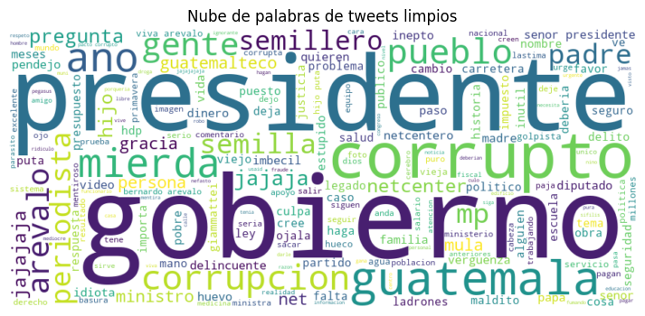

```python
text_for_wc = ' '.join(df['tweet_text_clean'].tolist())
wc = WordCloud(width=900, height=400, background_color='white').generate(text_for_wc)
plt.figure(figsize=(10,4))
plt.imshow(wc, interpolation='bilinear')
plt.axis('off')
plt.title('Nube de palabras de tweets limpios')
plt.show()
```

```python
# Diccionario de palabras y frecuencias relativas
frecuencias = wc.words_
print(type(frecuencias))
print(list(frecuencias.items())[:10])
```

```
<class 'dict'>
[('gobierno', 1.0), ('presidente', 0.9232954545454546), ('corrupto', 0.6590909090909091), ('guatemala', 0.6477272727272727), ('ano', 0.4772727272727273), ('mierda', 0.4659090909090909), ('corrupcion', 0.4318181818181818), ('pueblo', 0.42613636363636365), ('gente', 0.3693181818181818), ('arevalo', 0.…
```

```python
activity = (
    df.dropna(subset=['date'])
      .assign(hour=lambda d: d['date'].dt.hour)
      .groupby('hour')['id_str']
      .count()
      .reset_index(name='tweets')
)
```

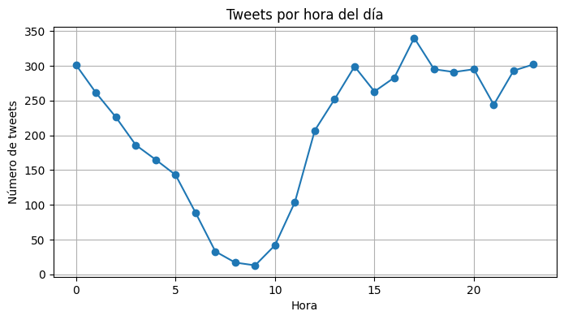

```python
plt.figure(figsize=(8,4))
plt.plot(activity['hour'], activity['tweets'], marker='o')
plt.title('Tweets por hora del día')
plt.xlabel('Hora')
plt.ylabel('Número de tweets')
plt.grid(True)
plt.show()
```

Podemos observar en la gráfica que la hora más activa para este tipo de tweets es por la tarde y por la madrugada. Existe una excases de tweets por la mañana.

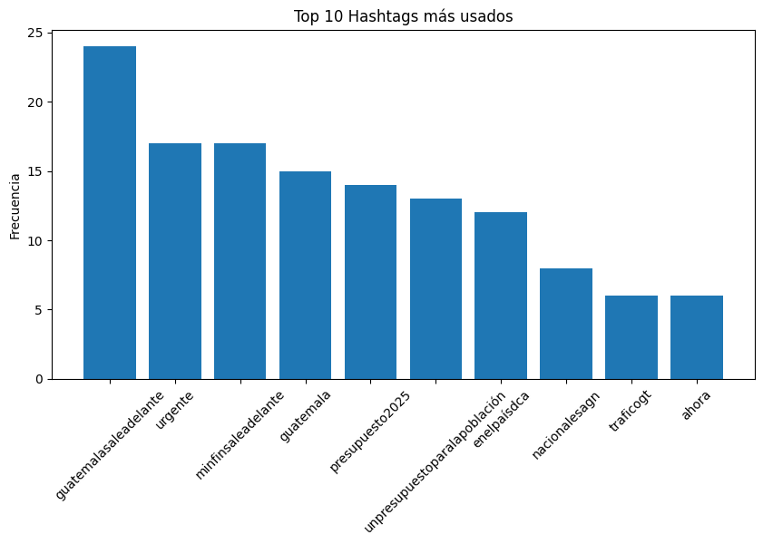

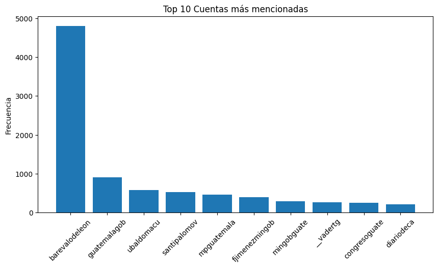

```python
# --- Hashtags ---
top_hashtags = Counter(all_hashtags).most_common(10)
df_hashtags = pd.DataFrame(top_hashtags, columns=['Hashtag', 'Frecuencia'])

plt.figure(figsize=(10,5))
plt.bar(df_hashtags['Hashtag'], df_hashtags['Frecuencia'])
plt.title("Top 10 Hashtags más usados")
plt.xticks(rotation=45)
plt.ylabel("Frecuencia")
plt.show()

# --- Menciones ---
top_mentions = Counter([m for ms in df['mentionedUsers'] for m in ms]).most_common(10)
df_mentions = pd.DataFrame(top_mentions, columns=['Usuario', 'Frecuencia'])

plt.figure(figsize=(10,5))
plt.bar(df_mentions['Usuario'], df_mentions['Frecuencia'])
plt.title("Top 10 Cuentas más mencionadas")
plt.xticks(rotation=45)
plt.ylabel("Frecuencia")
plt.show()
```

```python
tweets_por_usuario = df['user'].value_counts()

# Top 10 usuarios más activos
top_usuarios = tweets_por_usuario.head(10)

print("Top 10 usuarios con más tweets:")
print(top_usuarios)
```

```
Top 10 usuarios con más tweets:
user
elrevoltijogt      40
benitoc67601310    31
ialmgg             21
minfingt           20
vvj_gt             18
dupin07            18
arronchopa         16
dimb502            16
spaceboy88fly      16
anti_chairosgt     16
Name: count, dtype: int64
```

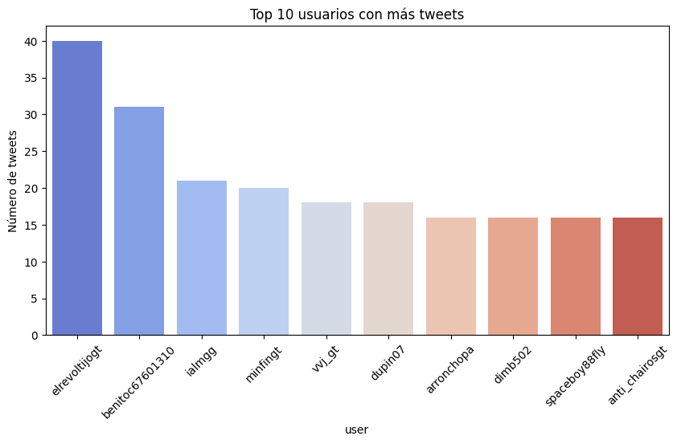

```python
plt.figure(figsize=(10,5))
sns.barplot(x=top_usuarios.index, y=top_usuarios.values, palette="coolwarm")
plt.title("Top 10 usuarios con más tweets")
plt.xticks(rotation=45)
plt.ylabel("Número de tweets")
plt.show()
```

```python
num_conversaciones = df['conversationIdStr'].nunique()

print("Número de conversaciones únicas:", num_conversaciones)
```

```
Número de conversaciones únicas: 971
```

El numero de conversasiones (971) es un indicador de que la mayoria de los tweets son pertenecientes a interacciones entre ellos, es decir, son respuestas a los mismos tweets que se encuentran en la lista, los usuarios interaccionan bastante.